# Inferential Statistics Ia - Frequentism

## Learning objectives

This assignment takes you on a brief journey through frequentist statistics. You will explore

- the *z*-statistic
- the *t*-statistic
- the difference and relationship between the two
- the Central Limit Theorem, its assumptions and consequences
- how to estimate the population mean and standard deviation from a sample
- the concept of a sampling distribution of a test statistic, particularly for the mean
- how to combine these concepts to calculate a confidence interval

## Prerequisites

For working through this notebook, you are expected to have an understanding of:

- the idea of a random variable
- what a probability density function (pdf) is
- and the cumulative density function
- what the Normal distribution is at a high level

It will be helpful if you are familiar with the concept of a sampling distribution, but this assignment will introduce this and give you hands on experience. As such, this notebook will take you from a basic understanding of random variables, and probability and bridge the gap to applying it in Python before moving on to a real world application.

For this notebook, we will use data sampled from a known normal distribution. This allows us to compare our results with theoretical expectations.

## I An introduction to sampling from the Normal distribution

Firstly, how can we actually generate the Normal distribution? Whilst much interest within the machine learning community lies in [sklearn](https://scikit-learn.org/stable/), those of you perhaps coming from the sciences may have heard of [scipy](https://docs.scipy.org/doc/scipy-0.15.1/reference/index.html). In particular, here, we will be making use of [scipy.stats](https://docs.scipy.org/doc/scipy-0.15.1/reference/tutorial/stats.html)

```python
from scipy.stats import norm
from scipy.stats import t
import numpy as np
import pandas as pd
from numpy.random import seed
import matplotlib.pyplot as plt
```

**Q:** Call up the documentation for the `norm` function imported above. What is the second listed method?

```python
print(norm.__doc__)
```

[output not shown]

[output cut: 53 more lines]

```
    Check accuracy of ``cdf`` and ``ppf``:

    >>> vals = norm.ppf([0.001, 0.5, 0.999])
    >>> np.allclose([0.001, 0.5, 0.999], norm.cdf(vals))
    True

    Generate random numbers:

    >>> r = norm.rvs(size=1000)

    And compare the histogram:

    >>> ax.hist(r, density=True, histtype='stepfilled', alpha=0.2)
    >>> ax.legend(loc='best', frameon=False)
    >>> plt.show()
```

**A:** Probability density function is the second function

**Q:** Use the method that generates random variates to draw five samples from the standard normal distribution.

**A:**

```python
seed(47)
# draw five samples here
random_sample = norm.rvs(size=5)
print(random_sample)
```

```
[-0.84800948  1.30590636  0.92420797  0.6404118  -1.05473698]
```

**Q:** What is the mean of this sample? Is it exactly equal to the value you expected? Hint: the sample was drawn from the standard normal distribution.

**A:**

```python
# Calculate and print the mean here, hint: use np.mean()
random_mean = np.mean(random_sample)
print(random_mean)
```

```
0.19355593334131074
```

**Q:** What is the standard deviation of these numbers? Calculate this manually here as $\sqrt{\frac{\sum_i(x_i - \bar{x})^2}{n}}$. Hint: np.sqrt() and np.sum() will be useful here and remember that numpy supports [broadcasting](https://docs.scipy.org/doc/numpy/user/basics.broadcasting.html).

**A:**

```python
np.sqrt(np.sum((random_sample - random_mean)**2)/len(random_sample))
```

```
0.9606195639478641
```

Here we have calculated the actual standard deviation of a small (size 5) data set. But in this case, this small data set is actually a sample from our larger (infinite) population. The population in this case is infinite because we could keep drawing our normal random variates until our computers died. In general, the sample mean we calculate will not be equal to the population mean (as we saw above). A consequence of this is that the sum of squares of the deviations from the *population* mean will be bigger than the sum of squares of the deviations from the *sample* mean. In other words, the sum of squares of the deviations from the *sample* mean is too small to give an unbiased estimate of the *population* variance. An example of this effect is given [here](https://en.wikipedia.org/wiki/Bessel%27s_correction#Source_of_bias). Scaling our estimate of the variance by the factor $n/(n-1)$ gives an unbiased estimator of the population variance. This factor is known as [Bessel's correction](https://en.wikipedia.org/wiki/Bessel%27s_correction). The consequence of this is that the $n$ in the denominator is replaced by $n-1$.

**Q:** If all we had to go on was our five samples, what would be our best estimate of the population standard deviation? Use Bessel's correction ($n-1$ in the denominator), thus $\sqrt{\frac{\sum_i(x_i - \bar{x})^2}{n-1}}$.

**A:**

```python
np.sqrt(np.sum((random_sample - random_mean)**2)/(len(random_sample)-1))
```

```
1.0740053227518152
```

**Q:** Now use numpy's std function to calculate the standard deviation of our random samples. Which of the above standard deviations did it return?

**A:**

```python
np.std(random_sample)
```

```
0.9606195639478641
```

**Q:** Consult the documentation for np.std() to see how to apply the correction for estimating the population parameter and verify this produces the expected result.

**A:**

```python
np.std(random_sample, ddof=1)
```

```
1.0740053227518152
```

```python
# Means Delta Degrees of Freedom returns the correct output
```

### Summary of section

In this section you've been introduced to the scipy.stats package and used it to draw a small sample from the standard normal distribution. You've calculated the average (the mean) of this sample and seen, hopefully unsurprisingly, that this is not exactly equal to the expected population parameter (which we know because we're generating the random variates from a specific, known distribution). You've been introduced to two ways of calculating the standard deviation; one uses $n$ in the denominator and the other uses $n-1$ (Bessel's correction). You've also seen which of these calculations np.std() performs by default and how to get it to generate the other.

You use $n$ as the denominator if you want to calculate the standard deviation of a sequence of numbers. You use $n-1$ if you are using this sequence of numbers to estimate the population parameter. This brings us to some terminology that is extremely easy to get confused by.

The population parameter is traditionally written as $\sigma$ and the sample statistic as $s$. Rather unhelpfully, $s$ is also called the sample standard deviation (using $n-1$) whereas the standard deviation of the sample uses $n$. That's right, we have the sample standard deviation and the standard deviation of the sample and they're not the same thing! Yes, tell me about it.

The sample standard deviation \begin{equation} s = \sqrt{\frac{\sum_i(x_i - \bar{x})^2}{n-1}} \approx \sigma, \end{equation} is our best (unbiased) estimate of the population parameter ($\sigma$).

If your data set *is* your entire population, you simply want to calculate the population parameter, $\sigma$, via \begin{equation} \sigma = \sqrt{\frac{\sum_i(x_i - \bar{x})^2}{n}} \end{equation} as you have complete, full knowledge of your population. In other words, your sample *is* your population. It's worth noting at this point if your sample is your population then you know absolutely everything about your population, there are no probabilities really to calculate and no inference to be done.

If, however, you have sampled *from* your population, you only have partial knowledge of the state of your population and the standard deviation of your sample is not an unbiased estimate of the standard deviation of the population, in which case you seek to estimate that population parameter via the sample standard deviation, which uses the $n-1$ denominator.

By the way, we are now firmly in frequentist territory. I hope you've been dropping breadcrumbs.

## II Sampling distributions

So far we've been dealing with the concept of taking a sample from a population to infer the population parameters. One statistic we calculated for a sample was the mean. As our samples will be expected to vary from one draw to another, so will our sample statistics. If we were to perform repeat draws of size $n$ and calculate the mean of each, we would expect to obtain a distribution of values. This is the sampling distribution of the mean. The Central Limit Theorem (CLT) tells us that such a distribution will approach a normal distribution as $n$ increases. For the sampling distribution of the mean, the standard deviation of this distribution is given by

\begin{equation} \sigma_{mean} = \frac{\sigma}{\sqrt n} \end{equation}

where $\sigma_{mean}$ is the standard deviation of the sampling distribution of the mean and $\sigma$ is the standard deviation of the population (the population parameter).

This is important because typically we are dealing with samples from populations and all we know about the population is what we have in the sample. From this sample we wish to make inferences about the population. We may do this, for example, by looking at the histogram of the values and by calculating the mean and standard deviation (as estimates of the population parameters), and so we are intrinsically interested in how these quantities vary across samples. In other words, having taken one sample of size $n$ and made some claims about the general population, what if we were to take another sample of size $n$? Would we get the same result? Would we make the same claims about the general population? This brings us to a fundamental question: *when we make some inference about a population based on our sample, how confident can we be that we've got it 'right'?*

Let's give our normal distribution a little flavour. Also, for didactic purposes, the standard normal distribution, with its variance equal to its standard deviation of one would not be a great illustration of a key point. Let us imagine we live in a town of 50000 people and we know the height of everyone in this town. We will have 50000 numbers that tell us everything about our population. We'll simulate these numbers now and put ourselves in one particular town, called 'town 47', where the population mean height is 172 cm and population standard deviation is 5 cm.

```python
seed(47)
pop_heights = norm.rvs(172, 5, size=50000)
```

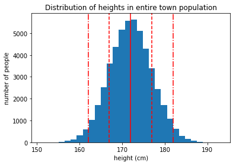

```python
_ = plt.hist(pop_heights, bins=30)
_ = plt.xlabel('height (cm)')
_ = plt.ylabel('number of people')
_ = plt.title('Distribution of heights in entire town population')
_ = plt.axvline(172, color='r')
_ = plt.axvline(172+5, color='r', linestyle='--')
_ = plt.axvline(172-5, color='r', linestyle='--')
_ = plt.axvline(172+10, color='r', linestyle='-.')
_ = plt.axvline(172-10, color='r', linestyle='-.')
```

Now, 50000 people is rather a lot to chase after with a tape measure and, frankly, like any good data scientist you're just a little bit lazy. If all you want to know is the average height of the townsfolk, then can you just go out and measure a sample to get a pretty good estimate of the average height?

```python
def townsfolk_sampler(n):
    return np.random.choice(pop_heights, n)
```

Let's say you go out one day and randomly sample 10 people to measure.

```python
seed(47)
daily_sample1 = townsfolk_sampler(10)
```

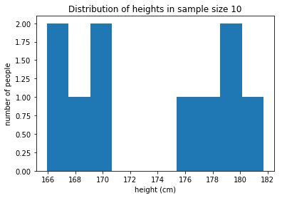

```python
_ = plt.hist(daily_sample1, bins=10)
_ = plt.xlabel('height (cm)')
_ = plt.ylabel('number of people')
_ = plt.title('Distribution of heights in sample size 10')
```

The sample distribution doesn't look much like what we know (but generally don't in real life) the population distribution looks like. What do we get for the mean?

```python
np.mean(daily_sample1)
```

```
173.47911444163503
```

And if we went out and repeated this experiment?

```python
daily_sample2 = townsfolk_sampler(10)
```

```python
np.mean(daily_sample2)
```

```
173.7317666636263
```

**Q:** Simulate performing this random trial every day for a year, calculating the mean of each daily sample of 10, and plot the resultant sampling distribution of the mean.

**A:**

```python
daily_sample3 = [townsfolk_sampler(10) for _ in range(365)]
```

```python
seed(47)
# take your samples here
yearly_sample = daily_sample3
print(yearly_sample)
```

[output not shown]

[output cut: 676 more lines]

[output not shown]

```python
print('Mean:', np.mean(yearly_sample))
print('Standard Deviation:', np.std(yearly_sample))
```

```
Mean: 171.86600493586488
Standard Deviation: 4.993357324234422
```

**Q:** Verify the above results from the CLT.

**A:**

```python
np.mean(daily_sample2)
```

```
173.7317666636263
```

```python
np.std(daily_sample2)
```

```
2.9825164114212668
```

**Q:** Repeat the above year's worth of samples but for a sample size of 50 (perhaps you had a bigger budget for conducting surveys that year!) Would you expect your distribution of sample means to be wider (more variable) or narrower (more consistent)? Compare your resultant summary statistics to those predicted by the CLT.

**A:**

```python
seed(47)
# calculate daily means from the larger sample size here
daily_sample4 = [townsfolk_sampler(50) for _ in range(365)]
```

```python
print('Mean:', np.mean(daily_sample4))
print('Standard Deviation:', np.std(daily_sample4))
```

```
Mean: 171.94366080916117
Standard Deviation: 4.991965467489464
```

### III Normally testing times!

All of the above is well and good. We've been sampling from a population we know is normally distributed, we've come to understand when to use $n$ and when to use $n-1$ in the denominator to calculate the spread of a distribution, and we've seen the Central Limit Theorem in action for a sampling distribution. All seems very well behaved in Frequentist land. But, well, why should we really care?

Remember, we rarely (if ever) actually know our population parameters; we have to estimate them somehow. If we want to make inferences such as "is this observation unusual?" or "has my population mean changed?" then we need to have some idea what the underlying distribution is so we can calculate relevant probabilities. In Frequentist land we use the formulas as above to deduce these population parameters. Let's remind ourselves how these probabilities work.

I hope you can remember some basic properties of the standard Normal distribution, such as about 68% of observations being within plus or minus 1 standard deviation of the mean.

**Q:** Using this fact, calculate the probability of observing the value 1 or less in a single observation from the standard normal distribution. Hint: you may find it helpful to sketch the standard normal distribution (the familiar bell shape) and mark the number of standard deviations from the mean on the x-axis and shade the regions of the curve that contain certain percentages of the population.

**A:**

[figure not shown]

```python
_ = plt.hist(daily_sample4, bins=30)
_ = plt.xlabel('height (cm)')
_ = plt.ylabel('number of people')
_ = plt.title('Distribution of heights in entire town population')
_ = plt.axvline(172, color='r')
_ = plt.axvline(172+5, color='r', linestyle='--')
_ = plt.axvline(172-5, color='r', linestyle='--')
_ = plt.axvline(172+10, color='r', linestyle='-.')
_ = plt.axvline(172-10, color='r', linestyle='-.')
```

Calculating this probability involved calculating the area under the pdf from the value of 1 and below. To put it another way, we need to integrate the pdf. We could just add together the known areas of chunks (from -Inf to 0 and then 0 to $+\sigma$ in the example above. One way to do this is using look up tables (literally). Fortunately, scipy has this functionality built in with the cdf() function.

**Q:** Use the cdf() function to answer the question above again and verify you get the same answer.

**A:**

```python
mean_daily_sample4 = np.mean(daily_sample4)
std_daily_sample4 = np.std(daily_sample4)
cdf = norm.cdf(daily_sample4, mean_daily_sample4, std_daily_sample4)
print(np.mean(cdf))
```

```
0.49917084523535565
```

**Q:** Using our knowledge of the population parameters for our townsfolk's heights, what is the probability of selecting one person at random and their height being 177 cm or less? Calculate this using both of the approaches given above.

**A:**

```python
pdf = norm.pdf(177, mean_daily_sample4, std_daily_sample4)
print("There's a", pdf * 100, "chance of selecting a person that is 177 cm or less")
```

```
There's a 4.784699996598552 chance of selecting a person that is 177 cm or less
```

**Q:** Turning this question around. Let's say we randomly pick one person and measure their height and find they are 2.00 m tall? How surprised should we be at this result, given what we know about the population distribution? In other words, how likely would it be to obtain a value at least as extreme as this? Express this as a probability.

**A:**

```python
pdf = norm.pdf(200, mean_daily_sample4, std_daily_sample4)
print("There's a", pdf * 100, "chance of selecting a person that is 200 cm or more")
```

```
There's a 1.1052055357628746e-06 chance of selecting a person that is 200 cm or more
```

We could calculate this probability by virtue of knowing the population parameters. We were then able to use the known properties of the relevant normal distribution to calculate the probability of observing a value at least as extreme as our test value. We have essentially just performed a z-test (albeit without having prespecified a threshold for our "level of surprise")!

We're about to come to a pinch, though here. We've said a couple of times that we rarely, if ever, know the true population parameters; we have to estimate them from our sample and we cannot even begin to estimate the standard deviation from a single observation. This is very true and usually we have sample sizes larger than one. This means we can calculate the mean of the sample as our best estimate of the population mean and the standard deviation (careful now! which one?) as our best estimate of the population standard deviation. In other words, we are now coming to deal with the sampling distributions we mentioned above as we are generally concerned with the properties of the sample means we obtain.

Above, we highlighted one result from the CLT, whereby the sampling distribution (of the mean) becomes narrower and narrower with the square root of the sample size. We remind ourselves that another result from the CLT is that *even if the underlying population distribution is not normal, the sampling distribution will tend to become normal with sufficiently large sample size*. This is the key driver for us 'requiring' a certain sample size, for example you may frequently see a minimum sample size of 30 stated in many places. In reality this is simply a rule of thumb; if the underlying distribution is approximately normal then your sampling distribution will already be pretty normal, but if the underlying distribution is heavily skewed then you'd want to increase your sample size.

**Q:** Let's now start from the position of knowing nothing about the heights of people in our town.

- Use our favourite random seed of 47, to randomly sample the heights of 50 townsfolk
- Estimate the population mean using np.mean
- Estimate the population standard deviation using np.std (remember which denominator to use!)
- Calculate the (95%) [margin of error](https://www.statisticshowto.datasciencecentral.com/probability-and-statistics/hypothesis-testing/margin-of-error/#WhatMofE) (use the exact critial z value to 2 decimal places - [look this up](https://www.statisticshowto.datasciencecentral.com/probability-and-statistics/find-critical-values/) or use norm.ppf())
- Calculate the 95% Confidence Interval of the mean
- Does this interval include the true population mean?

**A:**

```python
seed(47)
# take your sample now
daily_sample5 = townsfolk_sampler(50)
daily_sample5
```

```
array([179.04949004, 168.54189384, 181.71974048, 176.56433733,
       165.91968052, 170.65629646, 179.37664509, 166.40103988,
       177.15105034, 169.41097044, 169.96353026, 175.15960886,
       177.08203296, 175.57499516, 174.54290109, 172.47967099,
       168.61822612, 174.73274884, 170.88926244, 178.27468993,
       171.52874629, 173.48970606, 172.0752456 , 172.29707499,
       171.58202648, 169.84480352, 178.67104246, 174.28346436,
       174.29645483, 167.42082214, 168.57939161, 169.54392578,
       167.58621293, 176.8657094 , 164.25755366, 177.38929575,
       171.97964488, 164.94136054, 177.90675289, 175.2758845 ,
       176.64336688, 169.68013675, 175.41851966, 171.9408919 ,
       179.69843965, 169.93651872, 169.3320981 , 172.17010876,
       171.18783138, 171.14370134])
```

```python
mean_daily_sample5 = np.mean(daily_sample5)
mean_daily_sample5
```

```
172.7815108576788
```

```python
std_daily_sample5 = np.std(daily_sample5)
std_daily_sample5
```

```
4.153258225264712
```

```python
ppf = norm.ppf(.95, mean_daily_sample5, std_daily_sample5)
ppf
```

```
179.61301271317149
```

```python
norm.interval(1, ppf)
```

```
(-inf, inf)
```

**Q:** Above we calculated the confidence interval using the critical z value. What is the problem with this? What requirement, or requirements, are we (strictly) failing?

**A:**

**Q:** Calculate the 95% confidence interval for the mean using the *t* distribution. Is this wider or narrower than that based on the normal distribution above? If you're unsure, you may find this [resource](https://www.statisticshowto.datasciencecentral.com/probability-and-statistics/confidence-interval/) useful. For calculating the critical value, remember how you could calculate this for the normal distribution using norm.ppf().

**A:**

```python
seed(47)
# take your sample now
daily_sample6 = townsfolk_sampler(50)
daily_sample6
```

```
array([179.04949004, 168.54189384, 181.71974048, 176.56433733,
       165.91968052, 170.65629646, 179.37664509, 166.40103988,
       177.15105034, 169.41097044, 169.96353026, 175.15960886,
       177.08203296, 175.57499516, 174.54290109, 172.47967099,
       168.61822612, 174.73274884, 170.88926244, 178.27468993,
       171.52874629, 173.48970606, 172.0752456 , 172.29707499,
       171.58202648, 169.84480352, 178.67104246, 174.28346436,
       174.29645483, 167.42082214, 168.57939161, 169.54392578,
       167.58621293, 176.8657094 , 164.25755366, 177.38929575,
       171.97964488, 164.94136054, 177.90675289, 175.2758845 ,
       176.64336688, 169.68013675, 175.41851966, 171.9408919 ,
       179.69843965, 169.93651872, 169.3320981 , 172.17010876,
       171.18783138, 171.14370134])
```

```python
np.mean(daily_sample6)
```

```
172.7815108576788
```

```python
norm.ppf(.95, np.mean(daily_sample6), np.std(daily_sample6))
```

```
179.61301271317149
```

## Learning outcomes

Having completed this project notebook, you have good hands-on experience of

- how to sample from and calculate probabilities from a normal distribution
- the correct way to estimate the standard deviation of a population (the population parameter) from a sample
- what a sampling distribution is and how the Central Limit Theorem applies
- how to calculate critical values and confidence intervals